# Class 09: Structural Bioinformatics

Divya Shetty (A15390408)

2/16/2022

# Intro to RCSB Protein Data Bank

## PDB Statistics

Examine the CSV file taken from the PDB site.

```r
pdb <- read.csv("Data_Export_Summary.csv", row.names = 1)
pdb
```

```
##                          X.ray   NMR   EM Multiple.methods Neutron Other  Total
## Protein (only)          144433 11881 6732              182      70    32 163330
## Protein/Oligosaccharide   8543    31 1125                5       0     0   9704
## Protein/NA                7621   274 2165                3       0     0  10063
## Nucleic acid (only)       2396  1399   61                8       2     1   3867
## Other                      150    31    3                0       0     0    184
## Oligosaccharide (only)      11     6    0                1       0     4     22
```

**Q1: What percentage of structures in the PDB are solved by X-Ray and Electron Microscopy?**

```r
totals <- colSums(pdb)
totals/totals["Total"] * 100
```

```
##            X.ray              NMR               EM Multiple.methods
##      87.16888390       7.27787573       5.38868408       0.10632046
##          Neutron            Other            Total
##       0.03846770       0.01976813     100.00000000
```

About 87.17% of structures in the PDB are solved by X-Ray and 5.39% by Electron Microscopy.

**Q2: What proportion of structures in the PDB are protein?**

```r
#proportion
pdb$Total[1] / sum(pdb$Total)
```

```
## [1] 0.8726292
```

About 87.26% of the PDB structures are proteins.

**Q3: Type HIV in the PDB website search box on the home page and determine how many HIV-1 protease structures are in the current PDB?**

In the current PDB, there are 860 HIV-1 protease structures.

# Visualizing the HIV-1 Protease Structure

## Using Atom Selection

**Q4: Water molecules normally have 3 atoms. Why do we see just one atom per water molecule in this structure?**

In the structure, only the oxygen atoms are visualized, with the two hydrogen atoms not being included. This means there will only be one atom for each water molecule.

**Q5: There is a conserved water molecule in the binding site. Can you identify this water molecule? What residue number does this water molecule have (see note below)?**

The residue number is HOH332.

**Optional: Generate and save a figure clearly showing the two distinct chains of HIV-protease along with the ligand.**

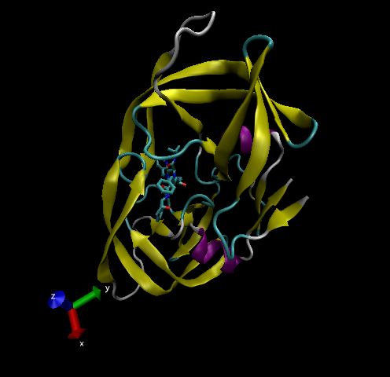

VMD rendered image of 1HSG

Discussion Topic: Can you think of a way in which indinavir, or even larger ligands and substrates, could enter the binding site?

# Intro to Bio3D in R

## Reading PDB File Data into R

Load the Bio3D package!

```r
#install.packages("bio3d")
library(bio3d)
```

Read a PDB file into R.

```r
hsg <- read.pdb("1hsg")
```

```
##   Note: Accessing on-line PDB file
```

```r
hsg
```

```
##
##  Call:  read.pdb(file = "1hsg")
##
##    Total Models#: 1
##      Total Atoms#: 1686,  XYZs#: 5058  Chains#: 2  (values: A B)
##
##      Protein Atoms#: 1514  (residues/Calpha atoms#: 198)
##      Nucleic acid Atoms#: 0  (residues/phosphate atoms#: 0)
##
##      Non-protein/nucleic Atoms#: 172  (residues: 128)
##      Non-protein/nucleic resid values: [ HOH (127), MK1 (1) ]
##
##    Protein sequence:
##       PQITLWQRPLVTIKIGGQLKEALLDTGADDTVLEEMSLPGRWKPKMIGGIGGFIKVRQYD
##       QILIEICGHKAIGTVLVGPTPVNIIGRNLLTQIGCTLNFPQITLWQRPLVTIKIGGQLKE
##       ALLDTGADDTVLEEMSLPGRWKPKMIGGIGGFIKVRQYDQILIEICGHKAIGTVLVGPTP
##       VNIIGRNLLTQIGCTLNF
##
## + attr: atom, xyz, seqres, helix, sheet,
##         calpha, remark, call
```

**Q7: How many amino acid residues are there in this pdb object?**

There are 198 amino acid residues in this object.

**Q8: Name one of the two non-protein residues?**

One of the non-protein residues is HOH, known as water.

**Q9: How many protein chains are in this structure?**

There are 2 protein chains.

Examine some of the attributes of the PDB object.

```r
attributes(hsg)
```

```
## $names
## [1] "atom"   "xyz"    "seqres" "helix"  "sheet"  "calpha" "remark" "call"
##
## $class
## [1] "pdb" "sse"
```

```r
head(hsg$atom)
```

```
##   type eleno elety  alt resid chain resno insert      x      y     z o     b
## 1 ATOM     1     N <NA>   PRO     A     1   <NA> 29.361 39.686 5.862 1 38.10
## 2 ATOM     2    CA <NA>   PRO     A     1   <NA> 30.307 38.663 5.319 1 40.62
## 3 ATOM     3     C <NA>   PRO     A     1   <NA> 29.760 38.071 4.022 1 42.64
## 4 ATOM     4     O <NA>   PRO     A     1   <NA> 28.600 38.302 3.676 1 43.40
## 5 ATOM     5    CB <NA>   PRO     A     1   <NA> 30.508 37.541 6.342 1 37.87
## 6 ATOM     6    CG <NA>   PRO     A     1   <NA> 29.296 37.591 7.162 1 38.40
##   segid elesy charge
## 1  <NA>     N   <NA>
## 2  <NA>     C   <NA>
## 3  <NA>     C   <NA>
## 4  <NA>     O   <NA>
## 5  <NA>     C   <NA>
## 6  <NA>     C   <NA>
```

# Comparative Structure Analysis of Adenylate Kinase

## Set-up

Install the following in the R console.

```r
#install.packages("ggrepel")
#install.packages("devtools")
#install.packages("BiocManager")

#BiocManager::install("msa")
#devtools::install_bitbucket("Grantlab/bio3d-view")
```

**Q10. Which of the packages above is found only on BioConductor and not CRAN?**

The “msa” package is found only on BioConductor.

**Q11. Which of the above packages is not found on BioConductor or CRAN?**

The “bio3d-view” package isn’t found on either BioConductor or CRAN.

**Q12. True or False? Functions from the devtools package can be used to install packages from GitHub and BitBucket?**

TRUE.

## Search & Retrieve ADK Structures

First, we need to find the sequence of chain A of 1AKE.

```r
aa <- get.seq("1ake_A")
```

```
## Fetching... Please wait. Done.
```

```r
aa
```

```
##              1        .         .         .         .         .         60
## pdb|1AKE|A   MRIILLGAPGAGKGTQAQFIMEKYGIPQISTGDMLRAAVKSGSELGKQAKDIMDAGKLVT
##              1        .         .         .         .         .         60
##
##             61        .         .         .         .         .         120
## pdb|1AKE|A   DELVIALVKERIAQEDCRNGFLLDGFPRTIPQADAMKEAGINVDYVLEFDVPDELIVDRI
##             61        .         .         .         .         .         120
##
##            121        .         .         .         .         .         180
## pdb|1AKE|A   VGRRVHAPSGRVYHVKFNPPKVEGKDDVTGEELTTRKDDQEETVRKRLVEYHQMTAPLIG
##            121        .         .         .         .         .         180
##
##            181        .         .         .   214
## pdb|1AKE|A   YYSKEAEAGNTKYAKVDGTKPVAEVRADLEKILG
##            181        .         .         .   214
##
## Call:
##   read.fasta(file = outfile)
##
## Class:
##   fasta
##
## Alignment dimensions:
##   1 sequence rows; 214 position columns (214 non-gap, 0 gap)
##
## + attr: id, ali, call
```

**Q13. How many amino acids are in this sequence, i.e. how long is this sequence?**

There are 214 amino acids in the sequence.

Now we can use this sequence to BLAST search the PDB database to find similar sequences.

```r
aa_blast <- blast.pdb(aa)
```

```
##  Searching ... please wait (updates every 5 seconds) RID = 11BYJ36J013
##  ...
##  Reporting 100 hits
```

We can visualize and filter the BLAST results using the function plot.blast().

```
##   * Possible cutoff values:    197 -3
##             Yielding Nhits:    16 100
##
##   * Chosen cutoff value of:    197
##             Yielding Nhits:    16
```

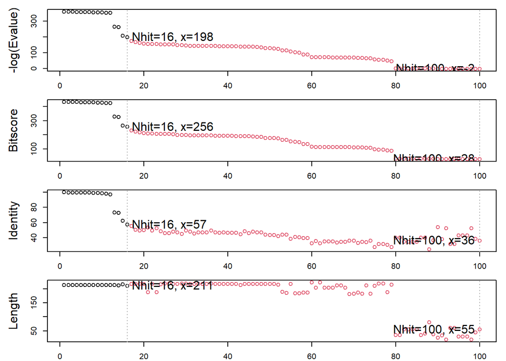

```r
hits <- plot.blast(aa_blast)
```

Here, we can see the top scoring hits from the BLAST results.

```r
head(hits$pdb.id)
```

```
## [1] "1AKE_A" "4X8M_A" "6S36_A" "6RZE_A" "4X8H_A" "3HPR_A"
```

With the above information, we can use get.pdb() to fetch and parse the dientified structures.

```r
# Download releated PDB files
files <- get.pdb(hits$pdb.id, path = "pdbs", split = TRUE, gzip = TRUE)
```

## Align and Superpose Structures

The code below will align and fit the identified PDB structures.

```r
#align PDBs
pdbs <- pdbaln(files, fit = TRUE, exefile = "msa")
```

```
## Reading PDB files:
## pdbs/split_chain/1AKE_A.pdb
## pdbs/split_chain/4X8M_A.pdb
## pdbs/split_chain/6S36_A.pdb
## pdbs/split_chain/6RZE_A.pdb
## pdbs/split_chain/4X8H_A.pdb
## pdbs/split_chain/3HPR_A.pdb
## pdbs/split_chain/1E4V_A.pdb
## pdbs/split_chain/5EJE_A.pdb
## pdbs/split_chain/1E4Y_A.pdb
## pdbs/split_chain/3X2S_A.pdb
## pdbs/split_chain/6HAP_A.pdb
## pdbs/split_chain/6HAM_A.pdb
## pdbs/split_chain/4K46_A.pdb
## pdbs/split_chain/4NP6_A.pdb
## pdbs/split_chain/3GMT_A.pdb
## pdbs/split_chain/4PZL_A.pdb
##    PDB has ALT records, taking A only, rm.alt=TRUE
## ..   PDB has ALT records, taking A only, rm.alt=TRUE
## .   PDB has ALT records, taking A only, rm.alt=TRUE
## ..   PDB has ALT records, taking A only, rm.alt=TRUE
## ..   PDB has ALT records, taking A only, rm.alt=TRUE
## ....   PDB has ALT records, taking A only, rm.alt=TRUE
## .   PDB has ALT records, taking A only, rm.alt=TRUE
## ....
##
## Extracting sequences
##
## pdb/seq: 1   name: pdbs/split_chain/1AKE_A.pdb
##    PDB has ALT records, taking A only, rm.alt=TRUE
## pdb/seq: 2   name: pdbs/split_chain/4X8M_A.pdb
## pdb/seq: 3   name: pdbs/split_chain/6S36_A.pdb
##    PDB has ALT records, taking A only, rm.alt=TRUE
## pdb/seq: 4   name: pdbs/split_chain/6RZE_A.pdb
##    PDB has ALT records, taking A only, rm.alt=TRUE
## pdb/seq: 5   name: pdbs/split_chain/4X8H_A.pdb
## pdb/seq: 6   name: pdbs/split_chain/3HPR_A.pdb
##    PDB has ALT records, taking A only, rm.alt=TRUE
## pdb/seq: 7   name: pdbs/split_chain/1E4V_A.pdb
## pdb/seq: 8   name: pdbs/split_chain/5EJE_A.pdb
##    PDB has ALT records, taking A only, rm.alt=TRUE
## pdb/seq: 9   name: pdbs/split_chain/1E4Y_A.pdb
## pdb/seq: 10   name: pdbs/split_chain/3X2S_A.pdb
## pdb/seq: 11   name: pdbs/split_chain/6HAP_A.pdb
## pdb/seq: 12   name: pdbs/split_chain/6HAM_A.pdb
##    PDB has ALT records, taking A only, rm.alt=TRUE
## pdb/seq: 13   name: pdbs/split_chain/4K46_A.pdb
##    PDB has ALT records, taking A only, rm.alt=TRUE
## pdb/seq: 14   name: pdbs/split_chain/4NP6_A.pdb
## pdb/seq: 15   name: pdbs/split_chain/3GMT_A.pdb
## pdb/seq: 16   name: pdbs/split_chain/4PZL_A.pdb
```

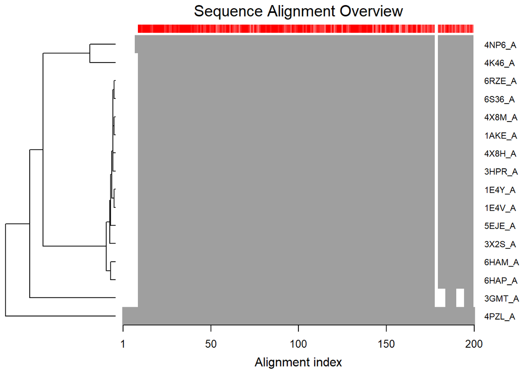

```r
#vector containing PDB codes for figure axis
ids <- basename.pdb(pdbs$id)

#draw schematic alignment
plot(pdbs, labels = ids)
```

## Viewing the Superposed Structures [OPTIONAL]

```r
#install.packages("devtools")
#library(devtools)
#install_bitbucket("Grantlab/bio3d-view")
#install.packages("rgl")

library(bio3d.view)
library(rgl)

view.pdbs(pdbs)
```

[viewer works! :)]

## Annotate PDB Structures

The functions below help us annotate the PDB structures so we can associate each structure with its source species.

```r
anno <- pdb.annotate(c("2mh3_A", "4f3l"), anno.terms = c("structureId", "experimentalTechnique", "resolution","pfam", "source", "citation"))
anno
```

```
##        structureId experimentalTechnique resolution
## 2MH3_A        2MH3                   NMR         NA
## 4F3L_B        4F3L                 X-ray      2.268
## 4F3L_A        4F3L                 X-ray      2.268
##                                             pfam       source
## 2MH3_A Helix-loop-helix DNA-binding domain (HLH) Homo sapiens
## 4F3L_B                       PAS domain (PAS_11) Mus musculus
## 4F3L_A                       PAS domain (PAS_11) Mus musculus
##                                   citation
## 2MH3_A Popovic, M., et al. Proteins (2014)
## 4F3L_B    Huang, N., et al. Science (2012)
## 4F3L_A    Huang, N., et al. Science (2012)
```

## Principal Component Analysis

We can use PCA on the identified PDBs in order to determine any significant structural variations.

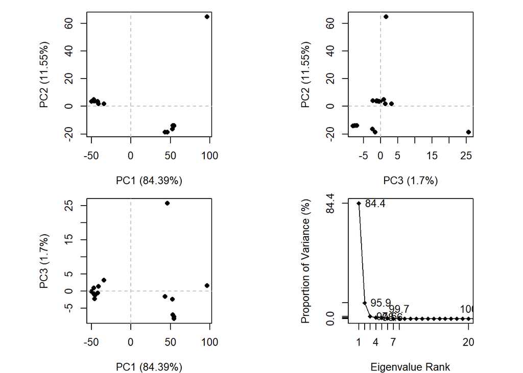

```r
pc.xray <- pca(pdbs)
plot(pc.xray)
```

We can calculate the pairwise RMSD values of the structures, which can help with clutering analysis.

```r
#calculate RMSD
rd <- rmsd(pdbs)
```

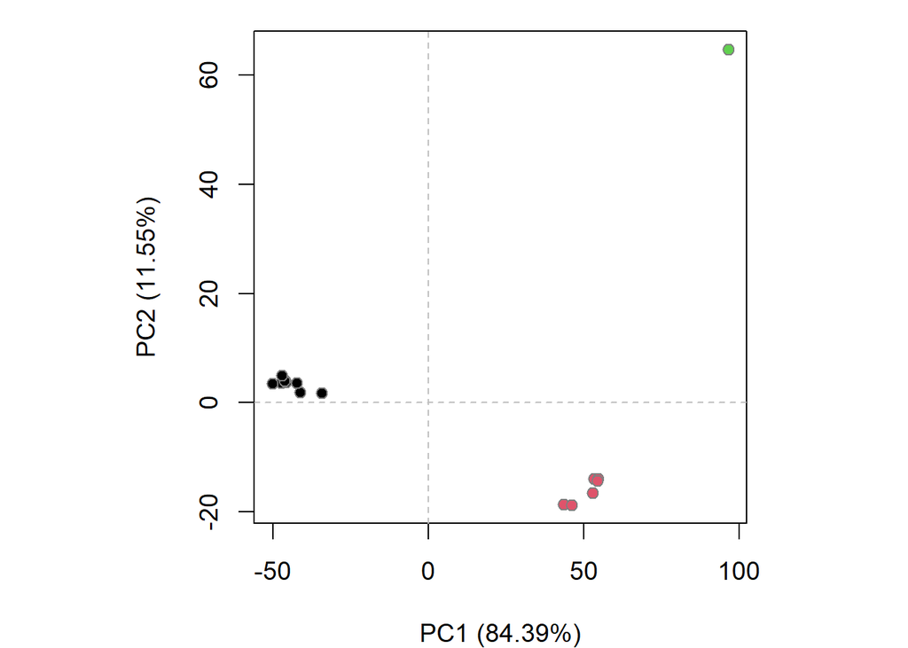

```r
#structure-based clustering
hc.rd <- hclust(dist(rd))
grps.rd <- cutree(hc.rd, k = 3)

plot(pc.xray, 1:2, col="grey50", bg = grps.rd, pch = 21, cex = 1)
```

# Normal Mode Analysis [OPTIONAL]

Normal Mode Analysis on PDBs can help with characterizing the profiles of related protein structures.

```r
modes <- nma(pdbs)
```

```
##
## Details of Scheduled Calculation:
##   ... 16 input structures
##   ... storing 606 eigenvectors for each structure
##   ... dimension of x$U.subspace: ( 612x606x16 )
##   ... coordinate superposition prior to NM calculation
##   ... aligned eigenvectors (gap containing positions removed)
##   ... estimated memory usage of final 'eNMA' object: 45.4 Mb
##
##
```

```
## Extracting SSE from pdbs$sse attribute
```

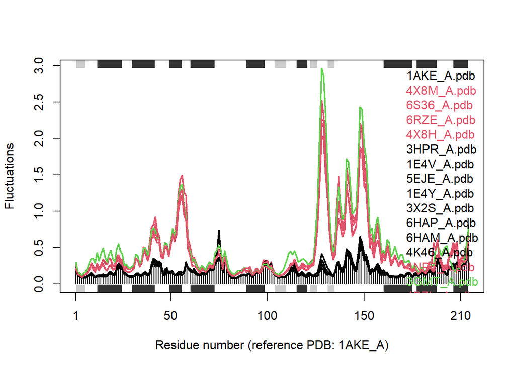

```r
plot(modes, pdbs, col = grps.rd)
```

**Q14. What do you note about this plot? Are the black and colored lines similar or different? Where do you think they differ most and why?**

The black lines and colored lines differ at certain regions, particularly from around residue numbers 30-70 and residue numbers 125-175. These differences may be due to those residues being associated with ligand binding sites for the structures represented by the colored lines.